# Analyse du sommeil

Aina Lariol

2023-11-09

# 1 Introduction

Nos jeux de données ici nous permet d’etudier la santé et le sommeil d’une population en fonction de leur activité professionnels, sportifs. On a 12 variables dont 7 variables quantitatives et 5 variables qualitatives. Les variables “Quality.of.sleep” , “Stress.Level” , “Heart.Rate” , “Daily.Steps” sont des variables quantitatives discretes qui peuvent être traités comme des variables qualitatives. Cependant dans notre analyse , on considère ces variables comme des variables quantitatives.

# 2 Analyse Univariée

```
##       Age        Sleep.Duration  Quality.of.Sleep Physical.Activity.Level
##  Min.   :27.00   Min.   :5.800   Min.   :4.000    Min.   :30.00
##  1st Qu.:35.25   1st Qu.:6.400   1st Qu.:6.000    1st Qu.:45.00
##  Median :43.00   Median :7.200   Median :7.000    Median :60.00
##  Mean   :42.18   Mean   :7.132   Mean   :7.313    Mean   :59.17
##  3rd Qu.:50.00   3rd Qu.:7.800   3rd Qu.:8.000    3rd Qu.:75.00
##  Max.   :59.00   Max.   :8.500   Max.   :9.000    Max.   :90.00
##   Stress.Level     Heart.Rate     Daily.Steps
##  Min.   :3.000   Min.   :65.00   Min.   : 3000
##  1st Qu.:4.000   1st Qu.:68.00   1st Qu.: 5600
##  Median :5.000   Median :70.00   Median : 7000
##  Mean   :5.385   Mean   :70.17   Mean   : 6817
##  3rd Qu.:7.000   3rd Qu.:72.00   3rd Qu.: 8000
##  Max.   :8.000   Max.   :86.00   Max.   :10000
```

L’age minimal de la personne étudiées est 27 ans tandis que la personne plus agée a 59 ans.La moyenne de tous les ages est de 42,18 ans. On observe que 50% des personnes ont entre 35,25 et 50 ans. Le temps du sommeil varie entre 5.8 et 8.5 heures.En moyenne le temps de sommeil est 7.132 heures et la moité des personnes dorment 7,2 heures par nuit

## 2.1 Les variables quantitatives

**Les moyennes de toutes les variables quantitatives**

```
##                     Age          Sleep.Duration        Quality.of.Sleep
##               42.184492                7.132086                7.312834
## Physical.Activity.Level            Stress.Level              Heart.Rate
##               59.171123                5.385027               70.165775
##             Daily.Steps
##             6816.844920
```

### 2.1.1 Valeur des déciles

```
##     Age Sleep.Duration Quality.of.Sleep Physical.Activity.Level Stress.Level
## 10%  31            6.1                6                      30            3
## 90%  54            8.2                9                      90            8
##     Heart.Rate Daily.Steps
## 10%         65        5000
## 90%         75        8000
```

10% des personnes moins sportives ne font que 5000 pas par jour alors que les 10% qui pratiquent beaucoup d’exercices physiques font 8000 pas.

### 2.1.2 Valeur des quartiles

```
##        Age Sleep.Duration Quality.of.Sleep Physical.Activity.Level Stress.Level
## 0%   27.00            5.8                4                      30            3
## 25%  35.25            6.4                6                      45            4
## 75%  50.00            7.8                8                      75            7
## 100% 59.00            8.5                9                      90            8
##      Heart.Rate Daily.Steps
## 0%           65        3000
## 25%          68        5600
## 75%          72        8000
## 100%         86       10000
```

#### 2.1.2.1 Qualité de sommeil

Sur un bareme de 10, la plus mauvaise qualité de sommeil observée est de 4, tandis que la meilleure est de 9.Les premiers 25% des personnes assignent entre 4 et 6 ce qui veut dire qu’elles estiment moyennement la qualité de leurs sommeils.Les derniers 25% qui pensent avoir une meilleur qualité de sommeil donnent une note de 8 à 9.

### 2.1.3 Duréé du Sommeil

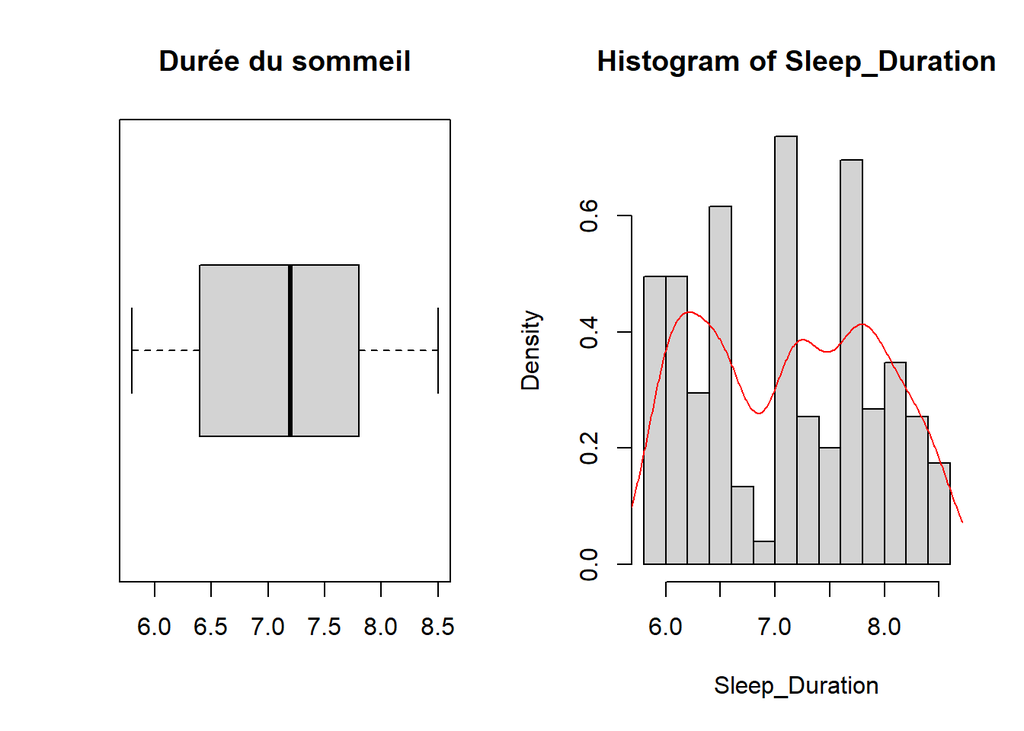

On a, ici, 3 modes de population autrement dit il y a 3 sous population de durée de sommeil donc la distribution est asymétrique.La premiere sous population formant 40% des personnes dormnent entre 5.8 à 6.8 heures, 20% des personnes dorment entre 6.8 à 7.3, ils forment la deuxiemme sous population. et enfin les 40% restants formant la troisième population dorment entre 7.3 et 9 heures.En moyenne les gens dorment 7,13 heures.

### 2.1.4 Rythme Cardiaque

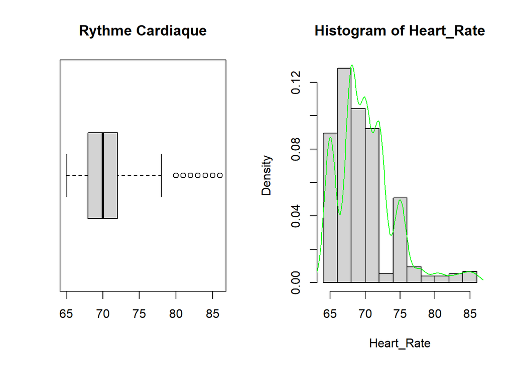

On observe que la distribution est asymetrique et elle est bimodale . En effet 50% des personnes ont un rythme cardiaque allant de 68 à 72 battements par minute, ils forment la première sous population. La deuxieme sous population ont 72 à 78 battements par minute, ils representent 25% de la population. Par contre on observe quelques personnes qui ont des battements de coeur jusqu’à 86 par minutes.

### 2.1.5 Age

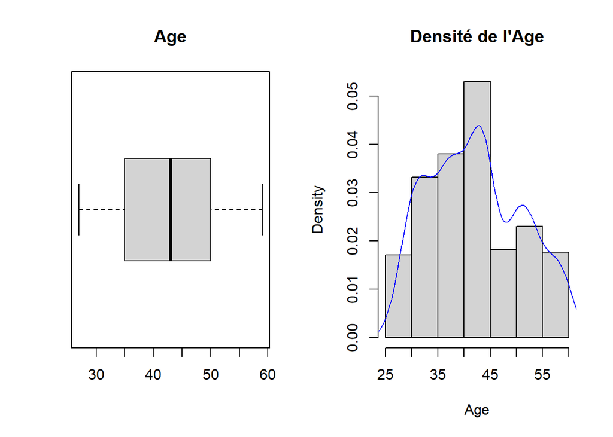

L’age moyen observé est de 42ans, la plus jeune etant de 27 ans et la plus vieille 59 ans. Ainsi notre distribution est asymétrique car ceux entre 27 et 45 ans, environ 60%, constituent la première sous population et ceux entre 46 et 60 ans , les 39% restants, constituent la deuxieme sous population.L’age moyen est de 42.18 ans.

## 2.2 Les variables qualitatives

### 2.2.1 Genre

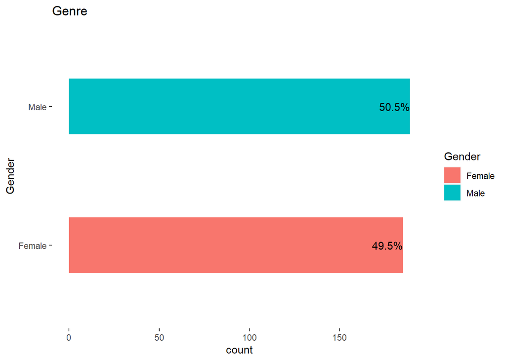

Les personnes de sexe masculin représentent 50,5% et les 49.5 restants sont de femmes.La repartition des classes ici est plus ou moins equilibrée.

### 2.2.2 Occupations

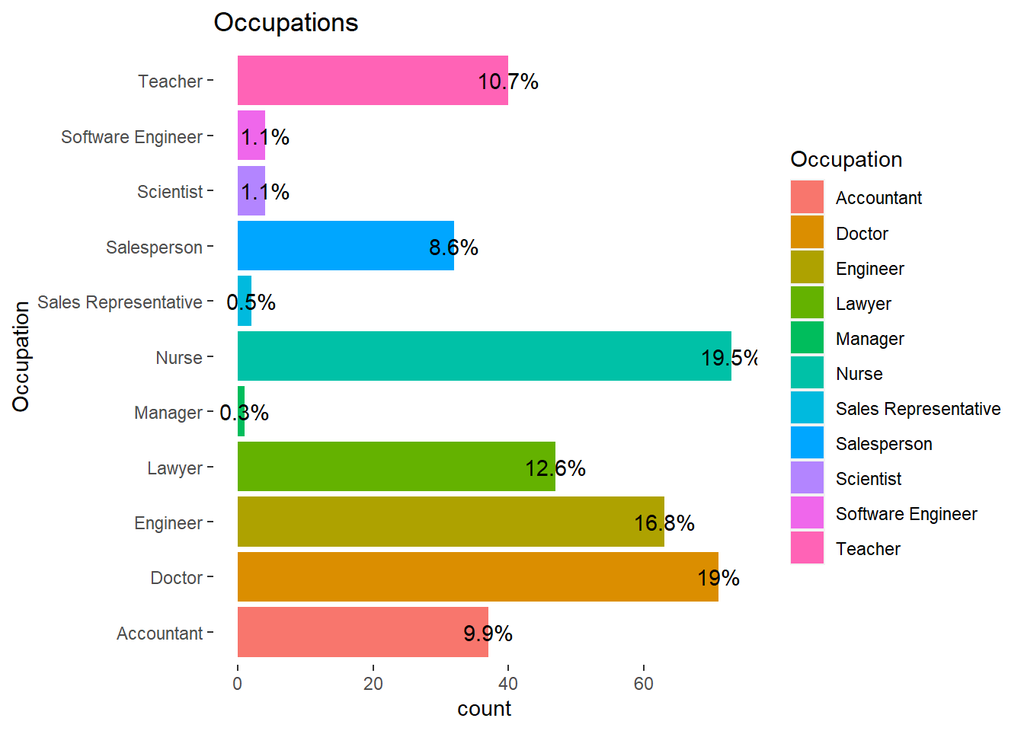

### 2.2.3 Indice IBM

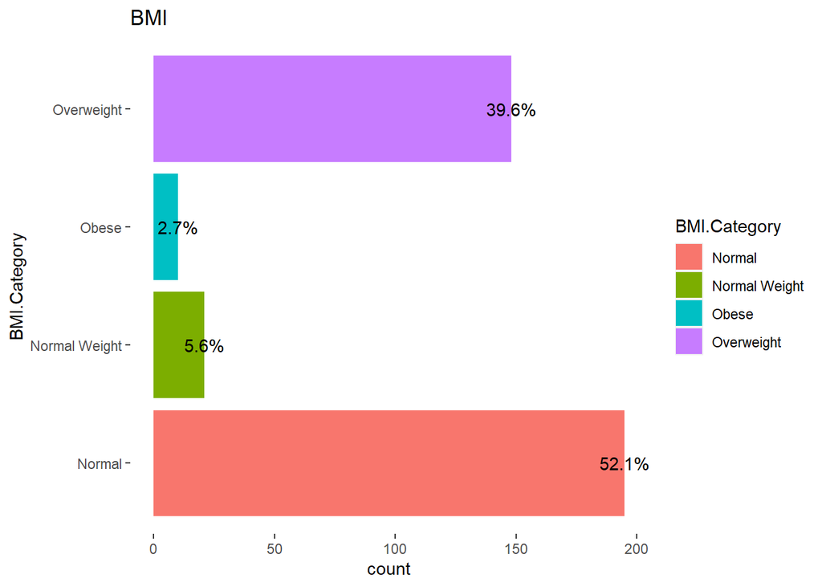

Plus de la moitié de l’echantillons ,c’est à dire 52.14%,ont une indice IBM normale.Seulement 5.61% sont en normal weight et les 42% restants mettent leurs vies en danger car 39.57% d’entre eux sont en surpoids extreme tandis que moins de 2.67% sont obèses. La distribution est fortement déséquilibrée.

### 2.2.4 Pression arterielle

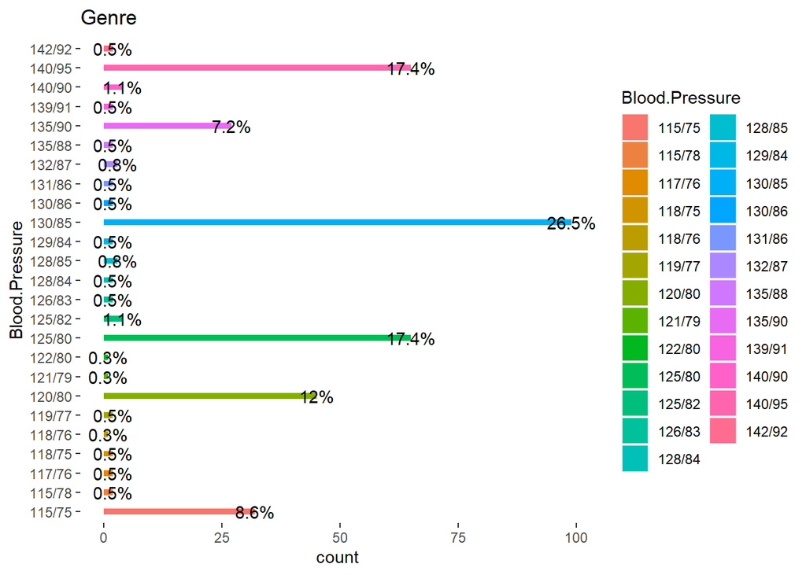

### 2.2.5 Trouble du sommeil

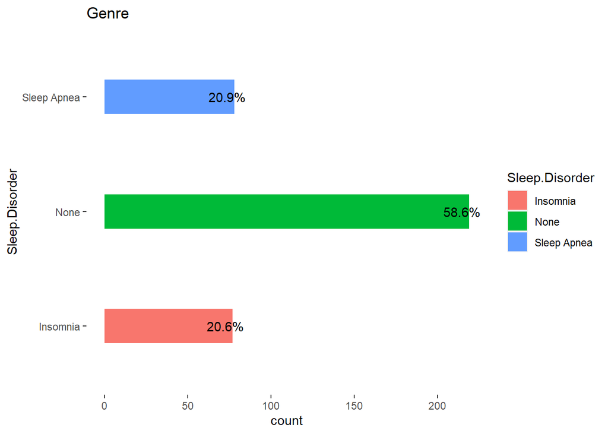

Plus de 58% des personnes observées dorment normalement, tandis que 20% atteinent l’appnée et les 20% restants sont insomniaque donc la distribution est désequilibrée.

# 3 Analyse Bivariée

## 3.1 Etude de 2 variables quantitatives

### 3.1.1 Correlation

```
##                                Age Sleep.Duration Quality.of.Sleep
## Age                      1.0000000     0.34470936       0.47373388
## Sleep.Duration           0.3447094     1.00000000       0.88321300
## Quality.of.Sleep         0.4737339     0.88321300       1.00000000
## Physical.Activity.Level  0.1789927     0.21236031       0.19289645
## Stress.Level            -0.4223445    -0.81102303      -0.89875203
## Heart.Rate              -0.2256062    -0.51645489      -0.65986473
## Daily.Steps              0.0579734    -0.03953254       0.01679141
##                         Physical.Activity.Level Stress.Level  Heart.Rate
## Age                                  0.17899272  -0.42234448 -0.22560619
## Sleep.Duration                       0.21236031  -0.81102303 -0.51645489
## Quality.of.Sleep                     0.19289645  -0.89875203 -0.65986473
## Physical.Activity.Level              1.00000000  -0.03413446  0.13697098
## Stress.Level                        -0.03413446   1.00000000  0.67002646
## Heart.Rate                           0.13697098   0.67002646  1.00000000
## Daily.Steps                          0.77272305   0.18682895 -0.03030858
##                         Daily.Steps
## Age                      0.05797340
## Sleep.Duration          -0.03953254
## Quality.of.Sleep         0.01679141
## Physical.Activity.Level  0.77272305
## Stress.Level             0.18682895
## Heart.Rate              -0.03030858
## Daily.Steps              1.00000000
```

D’après cette matrice on remarque les variables Sleep.Duration et Quality.of.sleep sont liées proportionnellement donc plus la qualité de sommeil augmente, la durée du sommeil augmentera aussi. Parcontre les variables quality.of.Sleep et Stress.level sont inversement proportionnelles car le niveau de stress affecte la qualité de sommeil, Plus on stresse plus on dort mal. On remarque également que il n’y a aucun impact sur la qualité du sommeil , les pas qu’ils ont fait quotidiennement.

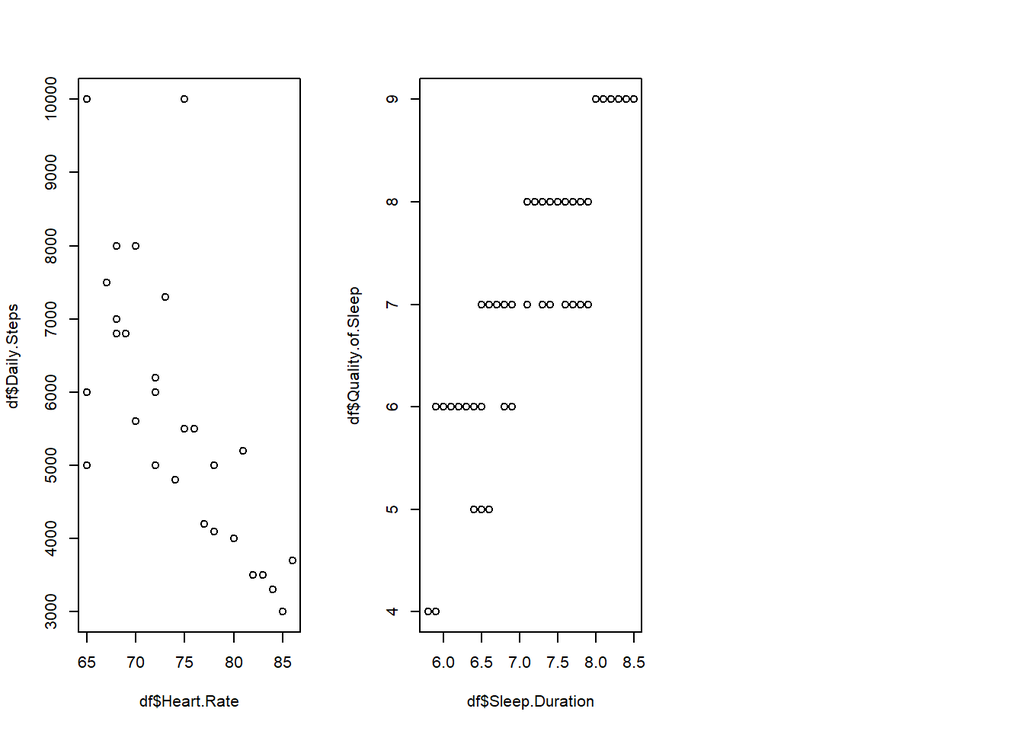

### 3.1.2 Dispersion de toutes les variables

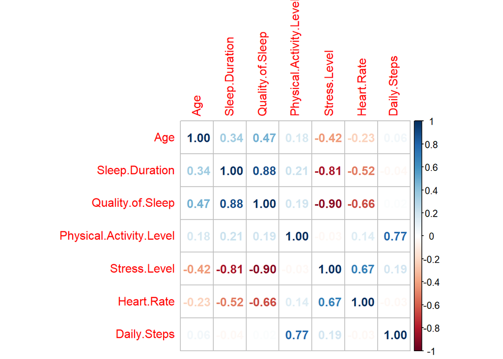

Les 2 coefficients de correlation linéaire les plus importantes: Stress.level et quality of sleep qui est de 0.90, quality of sleep et sleep.duration : 0.88

### 3.1.3 Test de Correlation

```
##
##  Pearson's product-moment correlation
##
## data:  df$Stress.Level and df$Quality.of.Sleep
## t = -39.535, df = 372, p-value < 2.2e-16
## alternative hypothesis: true correlation is not equal to 0
## 95 percent confidence interval:
##  -0.9166186 -0.8773022
## sample estimates:
##       cor
## -0.898752
```

Notre p_value est tres petit ce qui signifie qu’il y a une très forte correlation entre “Stress.Level et Quality.of.sleep, donc il y a une correlation significativeventre les 2 variables. La valeur de la correlation des 2 variables est bien comprise dans l’intervalle de confiance à 95% .Alors les 2 variables sont correlé negativement ce qui implique que si”Stress level” augmente ” Quality of sleep diminue et vice versa.

```
## $statistic
## [1] -11.2436
##
## $p.value
## [1] 1.245103e-29
```

### 3.1.4 Regression linéaire

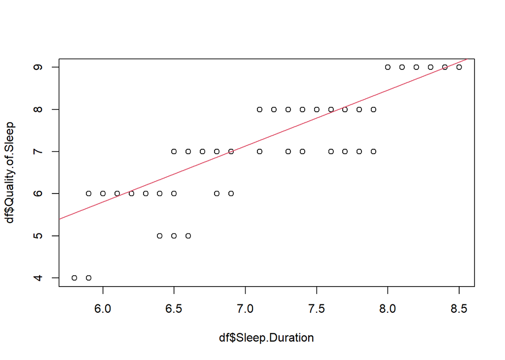

La droite de regression croissante ci-dessus confirme l’hypothèse precedente telle que si la qualité du sommeil augmente la durée de sommeil s’améliore aussi mais cela peut dépendre d’autres facteurs.

```
##
## Call:
## lm(formula = df$Quality.of.Sleep ~ df$Sleep.Duration, data = df)
##
## Residuals:
##      Min       1Q   Median       3Q      Max
## -1.67580 -0.20027  0.06546  0.40112  0.72980
##
## Coefficients:
##                   Estimate Std. Error t value Pr(>|t|)
## (Intercept)       -2.16337    0.26250  -8.242 2.94e-15 ***
## df$Sleep.Duration  1.32867    0.03658  36.324  < 2e-16 ***
## ---
## Signif. codes:  0 '***' 0.001 '**' 0.01 '*' 0.05 '.' 0.1 ' ' 1
##
## Residual standard error: 0.5621 on 372 degrees of freedom
## Multiple R-squared:  0.7801, Adjusted R-squared:  0.7795
## F-statistic:  1319 on 1 and 372 DF,  p-value: < 2.2e-16
```

## 3.2 Etude des variables qualitative et quantitative

**Gender** et **Sleep.Duration**

| x | x |
| --- | --- |
| Female | 7.229730 |
| Male | 7.036508 |

Les femmes dorment plus un quart d’heure de plus que les hommes car en moyenne elles dorment 7.22h tandis que les hommes dorment 7.03h,en plus les femmes stressent moins que les hommes avec un niveau de stress de 4.67 par rapport à 6.07 pour les hommes.

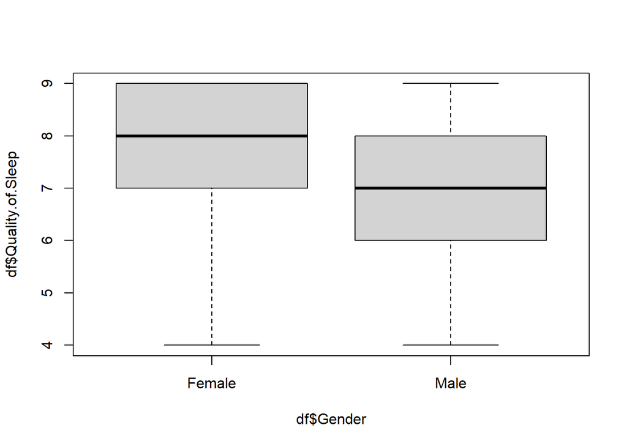

On a 2 boites à moustaches partiellement différentes , celle des femmes a la valeur la plus elevée autrement dit les femmes ont souvent une meillieur qualité de sommeil que les hommes, elles ont en moyenne une note de 8 alors que les hommes ont une note de 7. Les 50% au milieu ont entre 7 à 9 pour les femmes tandis que les hommes ont 6 à 8.Mais les 2 distributions sont asymétriques et indépendantes.

| x | x |
| --- | --- |
| Accountant | 7.891892 |
| Doctor | 6.647887 |
| Engineer | 8.412698 |
| Lawyer | 7.893617 |
| Manager | 7.000000 |
| Nurse | 7.369863 |
| Sales Representative | 4.000000 |
| Salesperson | 6.000000 |
| Scientist | 5.000000 |
| Software Engineer | 6.500000 |
| Teacher | 6.975000 |

D’après le tableau ci-dessus, les “Engineer” ont la meilleure qualité du sommeil, plus de 8.4/10 suivit des “Lawyer” avec 7.89/10. Les “Sales Reprensentative” ont la moins bonne qualité avec 4/10 et ce sont eux qui stressent le plus avec un niveau de stress de 8 . Avec un niveau de stress de 3.88 on peut dire que les “Engineer” stressent moins dans leurs occupations.

#### 3.2.0.1 Etudes des cas particulier:

**Etude sur les femmes qui dorment moins de 8 heurs par jours.**

```
##    Person.ID        Gender               Age         Occupation
##  Min.   : 17.0   Length:116         Min.   :29.00   Length:116
##  1st Qu.:120.8   Class :character   1st Qu.:37.00   Class :character
##  Median :234.0   Mode  :character   Median :44.00   Mode  :character
##  Mean   :201.7                      Mean   :42.90
##  3rd Qu.:276.8                      3rd Qu.:49.25
##  Max.   :312.0                      Max.   :52.00
##  Sleep.Duration  Quality.of.Sleep Physical.Activity.Level  Stress.Level
##  Min.   :5.800   Min.   :4.000    Min.   :30.00           Min.   :4.000
##  1st Qu.:6.100   1st Qu.:6.000    1st Qu.:45.00           1st Qu.:4.000
##  Median :6.600   Median :7.000    Median :60.00           Median :4.000
##  Mean   :6.624   Mean   :6.871    Mean   :61.78           Mean   :5.655
##  3rd Qu.:7.100   3rd Qu.:8.000    3rd Qu.:90.00           3rd Qu.:8.000
##  Max.   :7.900   Max.   :8.000    Max.   :90.00           Max.   :8.000
##  BMI.Category       Blood.Pressure       Heart.Rate     Daily.Steps
##  Length:116         Length:116         Min.   :65.00   Min.   : 3300
##  Class :character   Class :character   1st Qu.:68.00   1st Qu.: 6000
##  Mode  :character   Mode  :character   Median :68.00   Median : 7000
##                                        Mean   :70.84   Mean   : 7272
##                                        3rd Qu.:75.00   3rd Qu.:10000
##                                        Max.   :84.00   Max.   :10000
##  Sleep.Disorder
##  Length:116
##  Class :character
##  Mode  :character
##
##
##
```

**La durée du sommeil selon leurs occupations**

```
## $Teacher
##    Min. 1st Qu.  Median    Mean 3rd Qu.    Max.
##   6.300   6.600   6.600   6.690   6.725   7.200
```

**Comparaison des données suivant le sexe**

```
## $Female
##       Age        Sleep.Duration Quality.of.Sleep Physical.Activity.Level
##  Min.   :29.00   Min.   :5.80   Min.   :4.000    Min.   :30.00
##  1st Qu.:39.00   1st Qu.:6.50   1st Qu.:7.000    1st Qu.:45.00
##  Median :50.00   Median :7.20   Median :8.000    Median :60.00
##  Mean   :47.41   Mean   :7.23   Mean   :7.665    Mean   :59.14
##  3rd Qu.:53.00   3rd Qu.:8.10   3rd Qu.:9.000    3rd Qu.:75.00
##  Max.   :59.00   Max.   :8.50   Max.   :9.000    Max.   :90.00
##   Stress.Level     Heart.Rate     Daily.Steps
##  Min.   :3.000   Min.   :65.00   Min.   : 3300
##  1st Qu.:3.000   1st Qu.:65.00   1st Qu.: 5500
##  Median :4.000   Median :68.00   Median : 7000
##  Mean   :4.676   Mean   :69.26   Mean   : 6841
##  3rd Qu.:6.000   3rd Qu.:73.00   3rd Qu.: 7000
##  Max.   :8.000   Max.   :84.00   Max.   :10000
##
## $Male
##       Age        Sleep.Duration  Quality.of.Sleep Physical.Activity.Level
##  Min.   :27.00   Min.   :5.900   Min.   :4.000    Min.   :30.0
##  1st Qu.:32.00   1st Qu.:6.300   1st Qu.:6.000    1st Qu.:45.0
##  Median :38.00   Median :7.200   Median :7.000    Median :60.0
##  Mean   :37.07   Mean   :7.037   Mean   :6.968    Mean   :59.2
##  3rd Qu.:43.00   3rd Qu.:7.700   3rd Qu.:8.000    3rd Qu.:75.0
##  Max.   :49.00   Max.   :8.100   Max.   :9.000    Max.   :90.0
##   Stress.Level     Heart.Rate     Daily.Steps
##  Min.   :3.000   Min.   :65.00   Min.   : 3000
##  1st Qu.:5.000   1st Qu.:70.00   1st Qu.: 6000
##  Median :6.000   Median :70.00   Median : 8000
##  Mean   :6.079   Mean   :71.05   Mean   : 6794
##  3rd Qu.:7.000   3rd Qu.:72.00   3rd Qu.: 8000
##  Max.   :8.000   Max.   :86.00   Max.   :10000
```

**Correlation des variables suivant le sexe**

```
## $Female
##                                Age Sleep.Duration Quality.of.Sleep
## Age                      1.0000000      0.4639972        0.4545716
## Sleep.Duration           0.4639972      1.0000000        0.9435023
## Quality.of.Sleep         0.4545716      0.9435023        1.0000000
## Physical.Activity.Level  0.2018410     -0.3524190       -0.2350990
## Stress.Level            -0.2173019     -0.8472709       -0.8911671
## Heart.Rate              -0.2276647     -0.6254743       -0.7370002
## Daily.Steps              0.1308087     -0.5032049       -0.3744034
##                         Physical.Activity.Level Stress.Level Heart.Rate
## Age                                   0.2018410   -0.2173019 -0.2276647
## Sleep.Duration                       -0.3524190   -0.8472709 -0.6254743
## Quality.of.Sleep                     -0.2350990   -0.8911671 -0.7370002
## Physical.Activity.Level               1.0000000    0.4378735  0.4758586
## Stress.Level                          0.4378735    1.0000000  0.8426096
## Heart.Rate                            0.4758586    0.8426096  1.0000000
## Daily.Steps                           0.8901975    0.5847063  0.4087654
##                         Daily.Steps
## Age                       0.1308087
## Sleep.Duration           -0.5032049
## Quality.of.Sleep         -0.3744034
## Physical.Activity.Level   0.8901975
## Stress.Level              0.5847063
## Heart.Rate                0.4087654
## Daily.Steps               1.0000000
##
## $Male
##                                 Age Sleep.Duration Quality.of.Sleep
## Age                      1.00000000      0.1260220        0.2776948
## Sleep.Duration           0.12602199      1.0000000        0.8123994
## Quality.of.Sleep         0.27769481      0.8123994        1.0000000
## Physical.Activity.Level  0.26334442      0.9312789        0.7612316
## Stress.Level            -0.32522732     -0.8241659       -0.8985440
## Heart.Rate               0.05610163     -0.3241208       -0.4889014
## Daily.Steps             -0.04977804      0.6203461        0.5740439
##                         Physical.Activity.Level Stress.Level  Heart.Rate
## Age                                   0.2633444   -0.3252273  0.05610163
## Sleep.Duration                        0.9312789   -0.8241659 -0.32412079
## Quality.of.Sleep                      0.7612316   -0.8985440 -0.48890138
## Physical.Activity.Level               1.0000000   -0.7343466 -0.26705939
## Stress.Level                         -0.7343466    1.0000000  0.32220019
## Heart.Rate                           -0.2670594    0.3222002  1.00000000
## Daily.Steps                           0.6415515   -0.4097779 -0.63187347
##                         Daily.Steps
## Age                     -0.04977804
## Sleep.Duration           0.62034606
## Quality.of.Sleep         0.57404389
## Physical.Activity.Level  0.64155148
## Stress.Level            -0.40977791
## Heart.Rate              -0.63187347
## Daily.Steps              1.00000000
```

Le tableau ci-dessus montre la correlation des variables quantitatives suivants le sexe. Pour les femmes les variables “quality of sleep” et “sleep duration” sont fortement corrélé avec un coefficient de correlation de 0.94 , plus la qualité du sommeil augmente , la durée du someil augmente aussi. Ainsi que les variables “Stress Level et quality of sleep” avec un coefficient de -0.89 donc plus le stress augmente la qualité du sommeil diminue.

Pour les hommes, les variables “physical activity level” et “sleep duration” sont fortement corrélé avec un coefficient de 0.93; et les variables “quality of sleep” et “stress level” comme les femmes . Alors , on peut dire que le stress a un grand impact sur le sommeil que ce soit des hommes ou des femmes.

#### 3.2.0.2 Rapport de correlation Quality of sleep et Gender

```
## $Female
## [1] 1.637074
##
## $Male
## [1] 0.9989868
```

```
## [1] 0.2870911
```

On a un indice de 0.287, on ne pourra pas affirmer avec certitude que les 2 variables sont independants, donc on ferra des test pour confirmer le resultat.

### 3.2.1 Test

```
##
##  F test to compare two variances
##
## data:  df$Quality.of.Sleep by df$Gender
## F = 1.6387, num df = 184, denom df = 188, p-value = 0.0008081
## alternative hypothesis: true ratio of variances is not equal to 1
## 95 percent confidence interval:
##  1.228542 2.186874
## sample estimates:
## ratio of variances
##           1.638734
```

Ici on a fixé le risque à 5% , et H0 : la qualité du sommeil est la même quelque soit le genre H1 : la qualité du sommeil est différente quelque soit le genre On a obtenu p-value = 0.0008 < 5% donc l’hypothèse H0 est rejetée donc il y a une difference entre la variance des 2 genres

```
##
##  Welch Two Sample t-test
##
## data:  df$Quality.of.Sleep by Gender
## t = 5.8593, df = 347.96, p-value = 1.078e-08
## alternative hypothesis: true difference in means between group Female and group Male is not equal to 0
## 95 percent confidence interval:
##  0.4627786 0.9304432
## sample estimates:
## mean in group Female   mean in group Male
##             7.664865             6.968254
```

La moyenne de la qualité de sommeil est bien différente entre les 2 genres

### 3.2.2 Modelisation

```
##
## Call:
## lm(formula = df$Quality.of.Sleep ~ df$Gender, data = df)
##
## Residuals:
##     Min      1Q  Median      3Q     Max
## -3.6649 -0.9683  0.0317  1.0317  2.0317
##
## Coefficients:
##               Estimate Std. Error t value Pr(>|t|)
## (Intercept)     7.6649     0.0843  90.927  < 2e-16 ***
## df$GenderMale  -0.6966     0.1186  -5.875 9.42e-09 ***
## ---
## Signif. codes:  0 '***' 0.001 '**' 0.01 '*' 0.05 '.' 0.1 ' ' 1
##
## Residual standard error: 1.147 on 372 degrees of freedom
## Multiple R-squared:  0.08489,    Adjusted R-squared:  0.08243
## F-statistic: 34.51 on 1 and 372 DF,  p-value: 9.416e-09
```

Residuals represente la différence entre valeurs observées et predites. La correlation de gender et quality of sleep sont considéré comme significatif car on a 3 etoiles ici

[output not shown]

## 3.3 Etudes de 2 variables qualitatives

| Occupation | BMI.Category | n |
| --- | --- | --- |
| Accountant | Normal | 26 |
| Accountant | Normal Weight | 5 |
| Accountant | Overweight | 6 |
| Nurse | Normal Weight | 7 |
| Nurse | Overweight | 66 |

**Repartition des Occupation suivant le sexe**

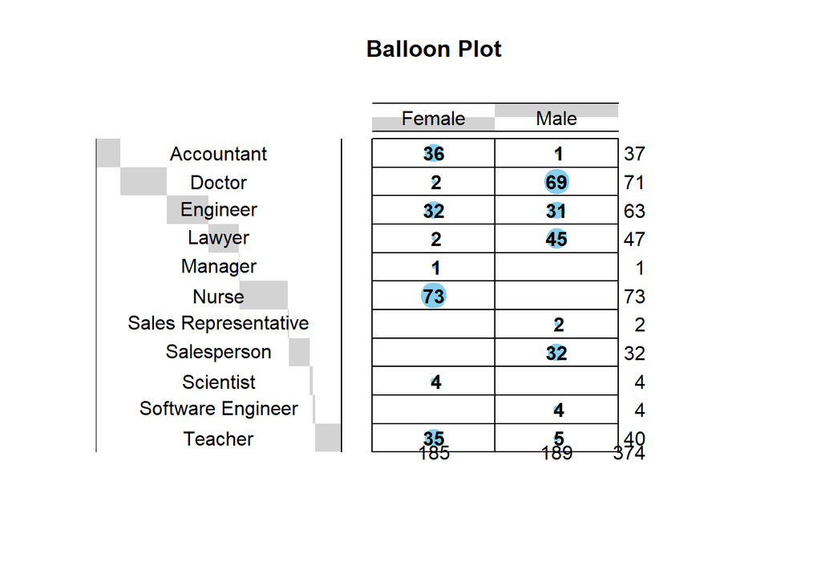

Parmis les personnes étudiées, on a 36 femmes comptables et un seul comptables,par contre on a que 2 docteurs femmes et 69 hommes. le nombre d’ingénieurs femmes et hommes est un peu équilibré avec 32 femmes et 31 hommes. On a qu’une seule Manager , ,73 Infirmières ainsi de suite . ce qui donne au total 185 femmes et 189 hommes.

### 3.3.1 Test de dépendance

```
##
##  Pearson's Chi-squared test
##
## data:  table(df$Gender, df$Sleep.Disorder)
## X-squared = 54.306, df = 2, p-value = 1.613e-12
```

```
## X-squared
## 0.3810555
```

On a toujours un p-value très petit avec la valeur de chi-carré très élévée ce qui suggère le niveau de dépendance des variables Gender et Sleep Disorder qui est assez forte.autrement dit Sleep disorder peut dépend du genre des personnes. Ainsi la force d’association entre ces 2 variables est moyennement modéré avec une valeur de 0.38